# Exploratory Data Analysis of City of Austin Water Quality

## 1) Introduction

Our group chose the Water Quality Sampling Data. After sifting through the variety of datasets offered to us by the city of Austin, we were drawn the most towards this dataset. We were interested in this data because of its relationship to the Austin environment. By analyzing this data, we can make informed decisions as civilians regarding our water usage and what we need to improve on in terms of city water quality. By using data analysis techniques and this dataset, we can become more educated about the source and quality of our drinking water and recreational bodies of water and track how water quality changes as the city continues to develop and grow over time.

Our main variables of interest in this dataset include DATE, WATERSHED, SITE_TYPE, PARAM_TYPE, PARAMETER, RESULT, and UNIT. Some of the question our data analysis will answer include:

1. Looking at the lakes, streams and springs in the greater Austin area, is there a difference between the results of water quality tests (Dissolved Carbon, Bacteria/Pathogen, pH, and Dissolved Oxygen) across these 3 different site types?
2. Across the three watershed Lake Austin, Lake Travis, and Lady Bird Lake, has the water quality in terms of dissolved oxygen changed over time overall in these 3 lakes?
3. Among the site types streams, lakes, and springs, is there a difference between what water quality tests are conducted and the number of tests and the site type?

## 2) Methods

```r
# For importing necessary library
library(readr)
library(tidyverse)
```

Loading the dataset so that we can begin exploring the data.

```r
# Loading the data set into a dataframe
water_quality_sampling_data <- read.csv('Water_Quality_Sampling_Data_20231020.csv')
```

Here we are just looking at and exploring the structure of the data to help us with cleaning later and selecting the variable we want to include in the final tidy dataset.

```r
# Looking at the structure of the data
str(water_quality_sampling_data)
```

```
## 'data.frame':    1440115 obs. of  23 variables:
##  $ DATA_REF_NO    : int  2308323 2308163 2308160 2308159 2308158 2308162 2308324 2308161 2308322 1031 ...
##  $ SAMPLE_REF_NO  : int  448739 448739 448739 448739 448739 448739 448739 448739 448739 88 ...
##  $ SAMPLE_DATE    : chr  "12/07/1947 12:00:00 AM" "12/07/1947 12:00:00 AM" "12/07/1947 12:00:00 AM" "12/07/1947 12:00:00 AM" ...
##  $ TIME_NULL      : chr  "Y" "Y" "Y" "Y" ...
##  $ WATERSHED      : chr  "Barton Creek" "Barton Creek" "Barton Creek" "Barton Creek" ...
##  $ SAMPLE_SITE_NO : int  735 735 735 735 735 735 735 735 735 35 ...
##  $ SITE_NAME      : chr  "USGS Well 301526097463201 (Rabb Well)" "USGS Well 301526097463201 (Rabb Well)" "USGS Well 301526097463201 (Rabb Well)" "USGS Well 301526097463201 (Rabb Well)" ...
##  $ LAT_DD_WGS84   : num  30.3 30.3 30.3 30.3 30.3 ...
##  $ LON_DD_WGS84   : num  -97.8 -97.8 -97.8 -97.8 -97.8 ...
##  $ SITE_TYPE      : chr  "Well" "Well" "Well" "Well" ...
##  $ PROJECT        : chr  "Groundwater" "Groundwater" "Groundwater" "Groundwater" ...
##  $ SAMPLE_ID      : chr  "" "" "" "" ...
##  $ DEPTH_IN_METERS: num  NA NA NA NA NA NA NA NA NA NA ...
##  $ MEDIUM         : chr  "Ground Water" "Ground Water" "Ground Water" "Ground Water" ...
##  $ PARAM_TYPE     : chr  "Nutrients" "Major Ions" "Major Ions" "Major Ions" ...
##  $ PARAMETER      : chr  "NITRATE AS N" "CHLORIDE" "SODIUM" "MAGNESIUM" ...
##  $ QUALIFIER      : chr  "" "" "" "" ...
##  $ RESULT         : num  1.5 14 10 20 55 20 241 244 220 0.24 ...
##  $ UNIT           : chr  "MG/L" "MG/L" "MG/L" "MG/L" ...
##  $ METHOD         : chr  "UNKNOWN" "UNKNOWN" "UNKNOWN" "UNKNOWN" ...
##  $ FILTER         : chr  "Total" "Total" "Total" "Total" ...
##  $ QC_TYPE        : chr  "" "" "" "" ...
##  $ QC_FLAG        : chr  "U" "U" "U" "U" ...
```

**Cleaning the dataset**

This dataset begins with 1440115 rows with 23 columns. We begin cleaning up the dataset for our anaylsis by selecting column variables we deem necessary for our data analysis. Since we are not interested in all the types of sites and test parameter types contained in the dataset, we filtered the dataset to only include the site types and test parameter types that we are interested in. After selecting all the relevant data for our analysis, we noticed that the SAMPLE_DATE column had values for both date and time so we separated them into their own columns and converted the dates into ‘Date’ data types for our time series analysis later. Once we performed all these steps, we found or data to be tidy since every observation had its own row and every variable had its own column. Our final tidy dataset contains 323437 rows and 15 variables.

```r
# Tidying/Wrangling/Manipulating dataset to get a clean/usable dataset

water_quality_sampling_data_tidy <- water_quality_sampling_data |>
    # selecting the column variables we are interested in our data analysis
    select(DATA_REF_NO, SAMPLE_REF_NO, SAMPLE_DATE, WATERSHED, SAMPLE_SITE_NO, SITE_NAME,
           LAT_DD_WGS84, LON_DD_WGS84, SITE_TYPE, DEPTH_IN_METERS, PARAM_TYPE, PARAMETER,
           RESULT, UNIT) |>
    # We are only interested in look at these Site types and test parameters
    filter(SITE_TYPE %in% c('Well', 'Spring', 'Stream', 'Lake', 'Cave Stream',
                            'Drinking Water Tap', 'Cave Pool','Cave Drip',
                            'Rainwater Catchment') &
           PARAM_TYPE %in% c('Nutrients', 'Major Ions', 'Solids/Conductivity',
                             'Alkalinity/Hardness/pH', 'Bacteria/Pathogens','Carbon',
                             'Metals', 'Oxygen', 'Hydrocarbons', 'Chlorinated',
                             'Insecticides', 'Fertilizers', 'Fungicides')) |>
    # Cleaning the SAMPLE_DATE column since it contains both the date and time
    separate(SAMPLE_DATE, into = c('DATE', 'TIME'), sep = ' ',
             convert = TRUE, extra = 'merge') |>
    # Converting the date information into a date object in R
    mutate(DATE = as.Date(DATE, format = '%m/%d/%Y'))
```

## 3) Results

### **Research Question 1:** Looking at the lakes, streams and springs in the greater Austin area, is there a difference between the results of water quality tests (Dissolved Carbon, Bacteria/Pathogen, pH, and Dissolved Oxygen) across these 3 different site types?

Since most of our visualizations for this question are positively skewed, we have decided to use the median and IQR as our summary statistics of interest. Also we have removed outliers before calculating summary statistics and performing visualizations since outliers in the analysis of our researc question were either incorrectly input test results, made the visualization unreadable, or were values that were deemed outliers by outlier filtering.

```r
# Visualization 1 for research question 1

# summary statistics for the `RESULT` of the `Carbon` water quality test excluding outliers
water_quality_sampling_data_tidy |>
  filter(PARAM_TYPE == 'Carbon' &
         SITE_TYPE %in% c('Lake', 'Stream', 'Spring') &
         PARAMETER == 'ORGANIC CARBON' &
         UNIT == 'MG/L') |>
  filter(RESULT >= quantile(RESULT, 0.25, na.rm = TRUE) - 1.5 * IQR(RESULT, na.rm = TRUE) &
         RESULT <= quantile(RESULT, 0.75, na.rm = TRUE) + 1.5 * IQR(RESULT, na.rm = TRUE)) |>
  group_by(SITE_TYPE) |>
  summarize(
        Min = min(RESULT, na.rm = TRUE),
        Q1 = quantile(RESULT, 0.25, na.rm = TRUE),
        Median = median(RESULT, na.rm = TRUE),
        Mean = mean(RESULT, na.rm = TRUE),
        Q3 = quantile(RESULT, 0.75, na.rm = TRUE),
        Max = max(RESULT, na.rm = TRUE))
```

```
## # A tibble: 3 × 7
##   SITE_TYPE   Min    Q1 Median  Mean    Q3   Max
##   <chr>     <dbl> <dbl>  <dbl> <dbl> <dbl> <dbl>
## 1 Lake       0.75  2.76   3.12  3.34  3.65  6.97
## 2 Spring     0.03  0.8    1.18  1.68  2    10.2
## 3 Stream     0.2   1.98   3.1   3.78  5.06 10.3
```

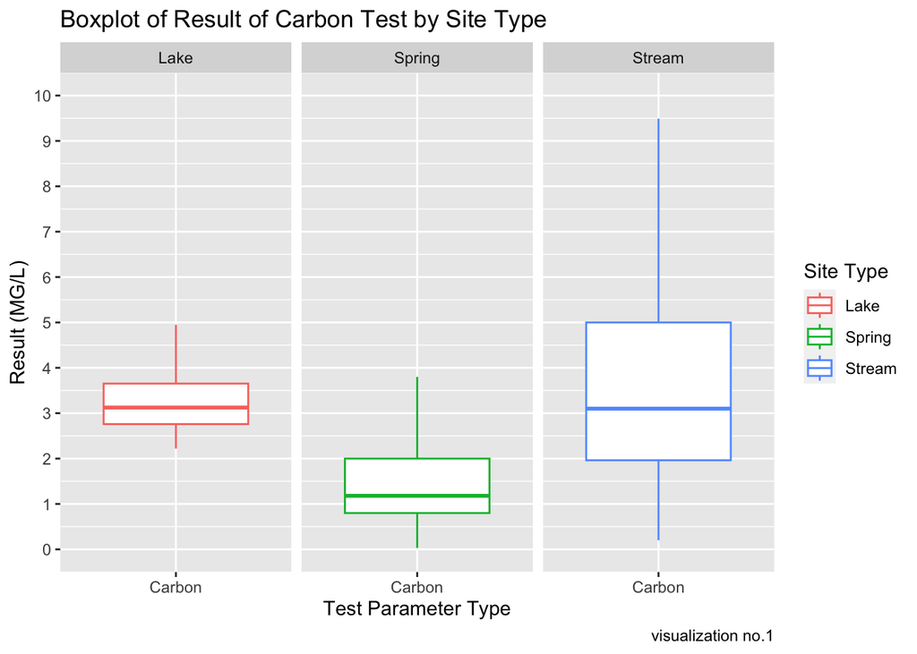

```r
# Generated a box plot for the result of the Carbon test across the 3 site types and removed outliers so that we can visualize the box plot better

water_quality_sampling_data_tidy |>
  filter(PARAM_TYPE == 'Carbon' &
         SITE_TYPE %in% c('Lake', 'Stream', 'Spring') &
         PARAMETER == 'ORGANIC CARBON' &
         UNIT == 'MG/L') |>
  filter(RESULT >= quantile(RESULT, 0.25, na.rm = TRUE) - 1.5 * IQR(RESULT, na.rm = TRUE) &
         RESULT <= quantile(RESULT, 0.75, na.rm = TRUE) + 1.5 * IQR(RESULT, na.rm = TRUE)) |>
  group_by(SITE_TYPE) |>
  ggplot() +
        # included outlier.shape = NA to remove outliers from plot
        geom_boxplot(aes(x = PARAM_TYPE, y = RESULT, color = SITE_TYPE),
                     outlier.shape = NA) +
        scale_y_continuous(limits = c(0, 10), breaks = seq(0,10,1)) +
        labs(title = 'Boxplot of Result of Carbon Test by Site Type',
             x = 'Test Parameter Type',
             y = 'Result (MG/L)',
             color = 'Site Type',
             caption = 'visualization no.1') +
        facet_wrap(~SITE_TYPE,  nrow = 1)
```

The site type lake has the highest median for carbon at 3.125 mg/L and an IQR of 0.8925 mg/L. This is followed by the stream with a median of 3.1 mg/L and IQR of 3.08 mg/L and lastly spring with a median of 1.18 mg/L and IQR of 1.2 mg/L. As you’ll notice in future visualizations, the spring site type tends to have much lower summary statistics and smaller spreads than the other two site types.

```r
# Visualization 2 for research question 1

# summary statistics for the `RESULT` of the `Bacteria/Pathogen` water quality test excluding outliers
water_quality_sampling_data_tidy |>
  filter(PARAM_TYPE == 'Bacteria/Pathogens' &
         SITE_TYPE %in% c('Lake', 'Stream', 'Spring') &
         UNIT == 'Colonies/100mL') |>
  filter(RESULT >= quantile(RESULT, 0.25, na.rm = TRUE) - 1.5 * IQR(RESULT, na.rm = TRUE) &
         RESULT <= quantile(RESULT, 0.75, na.rm = TRUE) + 1.5 * IQR(RESULT, na.rm = TRUE)) |>
  group_by(SITE_TYPE) |>
  summarize(
        Min = min(RESULT, na.rm = TRUE),
        Q1 = quantile(RESULT, 0.25, na.rm = TRUE),
        Median = median(RESULT, na.rm = TRUE),
        Mean = mean(RESULT, na.rm = TRUE),
        Q3 = quantile(RESULT, 0.75, na.rm = TRUE),
        Max = max(RESULT, na.rm = TRUE))
```

```
## # A tibble: 3 × 7
##   SITE_TYPE   Min    Q1 Median  Mean    Q3   Max
##   <chr>     <dbl> <dbl>  <dbl> <dbl> <dbl> <dbl>
## 1 Lake          0  10.8     42  74.9   100   410
## 2 Spring        0   4       12  40.2    40   410
## 3 Stream        0  15       45  80.1   108   413
```

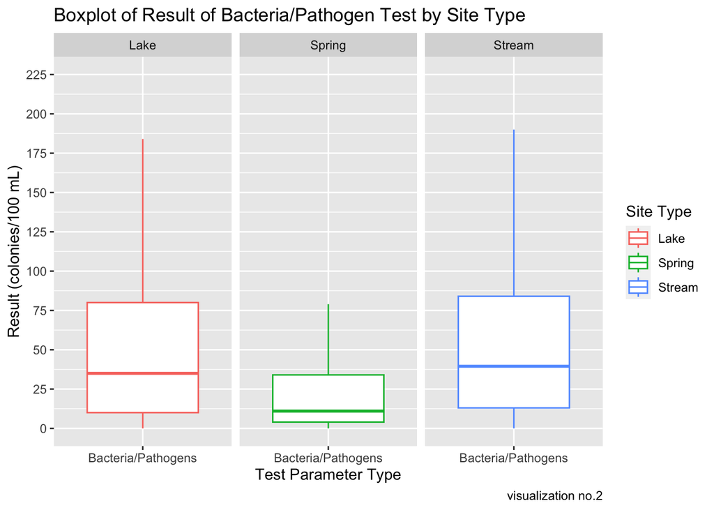

```r
# Generated a boxplot for the result of the Bacteria/Pathogen test across the 3 site types and removed outliers so that we can visualize the boxplot better

water_quality_sampling_data_tidy |>
  filter(PARAM_TYPE == 'Bacteria/Pathogens' &
         SITE_TYPE %in% c('Lake', 'Stream', 'Spring') &
         UNIT == 'Colonies/100mL') |>
  filter(RESULT >= quantile(RESULT, 0.25, na.rm = TRUE) - 1.5 * IQR(RESULT, na.rm = TRUE) &
         RESULT <= quantile(RESULT, 0.75, na.rm = TRUE) + 1.5 * IQR(RESULT, na.rm = TRUE)) |>
  group_by(SITE_TYPE) |>
  ggplot() +
        # included outlier.shape = NA to remove outliers from plot
        geom_boxplot(aes(x = PARAM_TYPE, y = RESULT, color = SITE_TYPE),
                     outlier.shape = NA) +
        scale_y_continuous(limits = c(0, 225), breaks = seq(0,225,25)) +
        labs(title = 'Boxplot of Result of Bacteria/Pathogen Test by Site Type',
             x = 'Test Parameter Type',
             y = 'Result (colonies/100 mL)',
             color = 'Site Type',
             caption = 'visualization no.2') +
        facet_wrap(~SITE_TYPE, nrow = 1)
```

Based on the boxplot of visualization 2, the spring site type again has the lowest median for the test results. There is also much overlap of spread between lake and stream site type, and the median and IQR are very similar. This maybe a result of the interconnections of lake and streams in Austin especially the streams that connect the major lakes together in Austin, which may result it similar test results.

```r
# Visualization 3 for research question 1

# summary statistics for the `RESULT` of the `Alkalinity/Hardness/pH` specifically the pH water quality tests excluding outliers
water_quality_sampling_data_tidy |>
  filter(PARAM_TYPE == 'Alkalinity/Hardness/pH' &
         PARAMETER %in% c('PH','24-HOUR AVG PH') &
         SITE_TYPE %in% c('Lake', 'Stream', 'Spring')) |>
  filter(RESULT >= quantile(RESULT, 0.25, na.rm = TRUE) - 1.5 * IQR(RESULT, na.rm = TRUE) &
         RESULT <= quantile(RESULT, 0.75, na.rm = TRUE) + 1.5 * IQR(RESULT, na.rm = TRUE)) |>
  group_by(SITE_TYPE) |>
  summarize(
        Min = min(RESULT, na.rm = TRUE),
        Q1 = quantile(RESULT, 0.25, na.rm = TRUE),
        Median = median(RESULT, na.rm = TRUE),
        Mean = mean(RESULT, na.rm = TRUE),
        Q3 = quantile(RESULT, 0.75, na.rm = TRUE),
        Max = max(RESULT, na.rm = TRUE))
```

```
## # A tibble: 3 × 7
##   SITE_TYPE   Min    Q1 Median  Mean    Q3   Max
##   <chr>     <dbl> <dbl>  <dbl> <dbl> <dbl> <dbl>
## 1 Lake       6.48  7.44   7.7   7.72  7.98  8.87
## 2 Spring     6.48  6.98   7.12  7.19  7.37  8.54
## 3 Stream     6.48  7.52   7.8   7.75  8     8.86
```

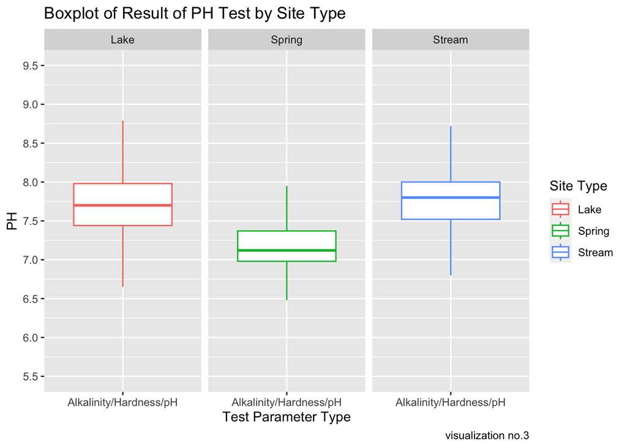

```r
# Generated a boxplot for the result of the Alkalinity/Hardness/pH test across the 3 site types and removed outliers so that we can visualize the boxplot better

water_quality_sampling_data_tidy |>
  filter(PARAM_TYPE == 'Alkalinity/Hardness/pH' &
         PARAMETER %in% c('PH','24-HOUR AVG PH') &
         SITE_TYPE %in% c('Lake', 'Stream', 'Spring')) |>
  filter(RESULT >= quantile(RESULT, 0.25, na.rm = TRUE) - 1.5 * IQR(RESULT, na.rm = TRUE) &
         RESULT <= quantile(RESULT, 0.75, na.rm = TRUE) + 1.5 * IQR(RESULT, na.rm = TRUE)) |>
  group_by(SITE_TYPE) |>
  ggplot() +
        # included outlier.shape = NA to remove outliers from plot
        geom_boxplot(aes(x = PARAM_TYPE, y = RESULT, color = SITE_TYPE),
                     outlier.shape = NA) +
        scale_y_continuous(limits = c(5.5,9.5), breaks = seq(5.5,9.5,0.5)) +
        labs(title = 'Boxplot of Result of PH Test by Site Type',
             x = 'Test Parameter Type',
             y = 'PH',
             color = 'Site Type',
             caption = 'visualization no.3') +
        facet_wrap(~SITE_TYPE,  nrow = 1)
```

The pH concentration in all three site types is very similar and has a much smaller spread. The stream site type has the highest pH with a median of 7.80 and an IQR of 0.48. The lake site type has a median pH of 7.70 and an IQR of 0.54 and lastly, the spring site type has a median pH of 7.12 and an IQR of 0.39. The pH of water should be around 7, which is where all three site types hover around.

```r
# Visualization 4 for research question 1

# summary statistics for the `RESULT` of the `Oxygen` water quality test excluding outliers
water_quality_sampling_data_tidy |>
  filter(PARAM_TYPE == 'Oxygen' &
         PARAMETER %in% c('24-HOUR AVG DISSOLVED OXYGEN','DISSOLVED OXYGEN') &
         UNIT == 'MG/L' &
         SITE_TYPE %in% c('Lake', 'Stream', 'Spring')) |>
  filter(RESULT >= quantile(RESULT, 0.25, na.rm = TRUE) - 1.5 * IQR(RESULT, na.rm = TRUE) &
         RESULT <= quantile(RESULT, 0.75, na.rm = TRUE) + 1.5 * IQR(RESULT, na.rm = TRUE)) |>
  group_by(SITE_TYPE) |>
  summarize(
        Min = min(RESULT, na.rm = TRUE),
        Q1 = quantile(RESULT, 0.25, na.rm = TRUE),
        Median = median(RESULT, na.rm = TRUE),
        Mean = mean(RESULT, na.rm = TRUE),
        Q3 = quantile(RESULT, 0.75, na.rm = TRUE),
        Max = max(RESULT, na.rm = TRUE))
```

```
## # A tibble: 3 × 7
##   SITE_TYPE   Min    Q1 Median  Mean    Q3   Max
##   <chr>     <dbl> <dbl>  <dbl> <dbl> <dbl> <dbl>
## 1 Lake       1.83  6.45   7.67  7.67  8.95  13.2
## 2 Spring     1.84  5.31   6.23  6.25  7.12  12.7
## 3 Stream     1.84  6.52   8     7.96  9.49  13.3
```

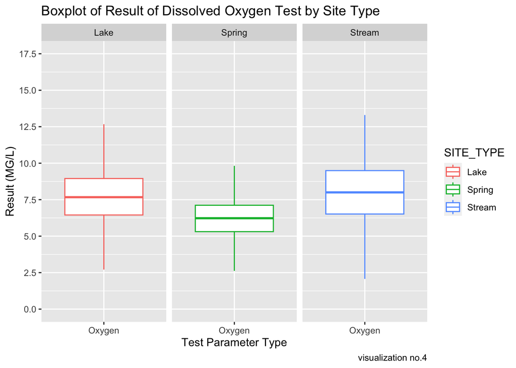

```r
# Generated a boxplot for the result of the Oxygen test across the 3 site types and removed outliers so that we can visualize the boxplot better

water_quality_sampling_data_tidy |>
  filter(PARAM_TYPE == 'Oxygen' &
         PARAMETER %in% c('24-HOUR AVG DISSOLVED OXYGEN','DISSOLVED OXYGEN') &
         UNIT == 'MG/L' &
         SITE_TYPE %in% c('Lake', 'Stream', 'Spring')) |>
  filter(RESULT >= quantile(RESULT, 0.25, na.rm = TRUE) - 1.5 * IQR(RESULT, na.rm = TRUE) &
         RESULT <= quantile(RESULT, 0.75, na.rm = TRUE) + 1.5 * IQR(RESULT, na.rm = TRUE)) |>   group_by(SITE_TYPE) |>
  ggplot() +
        # included outlier.shape = NA to remove outliers from plot
        geom_boxplot(aes(x = PARAM_TYPE, y = RESULT, color = SITE_TYPE),
                     outlier.shape = NA) +
        scale_y_continuous(limits = c(0, 17.5), breaks = seq(0,17.5,2.5)) +
        labs(title = 'Boxplot of Result of Dissolved Oxygen Test by Site Type',
             x = 'Test Parameter Type',
             y = 'Result (MG/L)',
             caption = 'visualization no.4') +
        facet_wrap(~SITE_TYPE,  nrow = 1)
```

The stream site type continues to have the highest median with a value of 8.00 mg/L and IQR of 2.975 mg/L for dissolved oxygen. The lake site type has a median of 7.67 mg/L and IQR of 2.50 mg/L. The spring site type has a median of 6.23 mg/L and an IQR of 1.8075 mg/L. This follows the pattern we have observed with the other water quality test types we are analyzing. It worth highlighting that a healthy amount of dissolved oxygen is between 6.5 - 8 mg/L.

On the boxplot of visualization 4, the spring site type has a lower median and spread, and has a lower dissolved oxygen concentration in comparison to the lake and stream. Stream and lakes have very similar boxplot structure, indicating that the dissolved oxygen content across both site type may be similar.

Overall, based on the 4 water quality tests we analyzed it seems that generally the results of the spring water quality tests are different from the results of the lakes and stream. On the other hand, after looking at the boxplot across all tests we analyzed, it seems that lakes and streams post very similar water quality results and this may indicate some relationship between the 2 site types in terms of water quality.